# Executive Summary

Author

Jakub Marciniak

Poznań’s rental market has emerged as one of **Poland’s most attractive investment destinations**, driven by strong fundamentals including a growing student population, expanding tech sector, and strategic location in western Poland. With over **100,000 students** and increasing numbers of young professionals, rental demand remains consistently high while supply struggles to keep pace.

*The analysis was performed on May 25th and contains all available listings in Poznan region at that point of time.*

## Setup and Data Loading

**Import libraries and load data**

```python
import pandas as pd
import matplotlib.pyplot as plt
from highlight_text import ax_text, fig_text
from drawarrow import ax_arrow, fig_arrow
from pypalettes import load_cmap
import geopandas as gpd
from pyfonts import load_font
import numpy as np
import ast
import seaborn as sns

plt.rcParams['figure.dpi'] = 72          # Lower DPI to reduce file size
plt.rcParams['savefig.dpi'] = 72         # Lower save DPI
plt.rcParams['savefig.bbox'] = 'tight'   # Tight bounding box

# Load custom fonts
poppins_light = load_font("https://github.com/google/fonts/blob/main/ofl/poppins/Poppins-Light.ttf?raw=true")
poppins_bold = load_font("https://github.com/google/fonts/blob/main/ofl/poppins/Poppins-Bold.ttf?raw=true")

# Load color palettes
cmap = load_cmap("Semicossyphus_pulcher", reverse=True)
cmap_unreversed = load_cmap("Semicossyphus_pulcher", reverse=False)
cmap_x85 = load_cmap("X85", reverse=True)

# Load and prepare data
df = pd.read_csv('data/listings_cleaned_data.csv')
df['Dzielnica'] = df['Dzielnica'].replace('Jeżyce', 'Jezyce')

print(f"Total number of listings: {len(df):,}")
```

```
Total number of listings: 1,366
```

## Market Overview

### Key Market Insights

The market has essentially standardized around a **“sweet spot” of ~45 m² apartments at ~2,500 PLN monthly rent**. Properties above 80 m² or 4,000 PLN represent a small niche segment, suggesting potential opportunities in the premium rental market remain underexplored.

**Create market overview histograms**

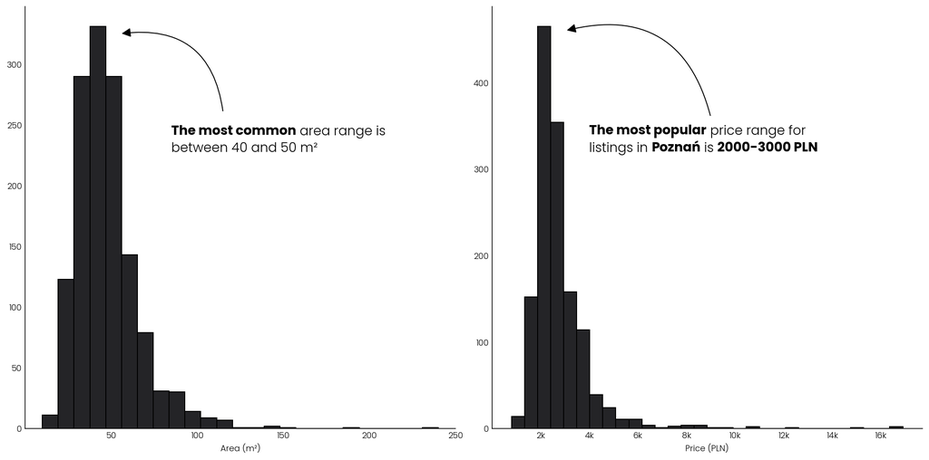

Distribution of apartment sizes and rental prices in Poznań

```python
# Filter extreme outliers
trimmed_df = df[df["Powierzchnia"] < 500]

fig, axs = plt.subplots(ncols=2, figsize=(14, 7))

def style_histogram_axes(ax, xlabel, fontsize=9, tick_font=poppins_light):
    """Apply common styling to histogram axes"""
    ax.set_xlabel(xlabel, fontsize=fontsize, font=poppins_light)
    ax.spines[['top', 'right']].set_visible(False)
    ax.tick_params(axis='both', labelsize=fontsize, length=0)

    if tick_font:
        for tick in ax.get_xticklabels():
            tick.set_font(tick_font)
            tick.set_fontsize(fontsize)
        for tick in ax.get_yticklabels():
            tick.set_font(tick_font)
            tick.set_fontsize(fontsize)

# Common histogram parameters
hist_params = {
    'bins': 25,
    'color': cmap(5),
    'edgecolor': 'black'
}

# Chart 1: Distribution of area sizes
ax_text(
    ax=axs[0],
    x=85, y=250,
    s="<The most common> area range is \nbetween 40 and 50 m²",
    fontsize=14,
    font=poppins_light,
    highlight_textprops=[{"color": 'black', 'font': poppins_bold}]
)

axs[0].hist(trimmed_df["Powierzchnia"].dropna(), **hist_params)
style_histogram_axes(axs[0], "Area (m²)")
axs[0].set_xlim(0, 250)

# Custom x-axis labels
labels_old = [0, 50, 100, 150, 200, 250]
labels_new = ["", "50", "100", "150", "200", "250"]
axs[0].set_xticks(labels_old, labels=labels_new)

ax_arrow([115, 260], [55, 325], ax=axs[0], color='black', radius=0.5)

# Chart 2: Distribution of rent prices
hist_params['bins'] = 30
axs[1].hist(df["Czynsz najmu"].dropna(), **hist_params)
style_histogram_axes(axs[1], "Price (PLN)")

# Custom x-axis labels for price chart
labels_old = [2000, 4000, 6000, 8000, 10000, 12000, 14000, 16000]
labels_new = ['2k', '4k', '6k', '8k', '10k', '12k', '14k', '16k']
axs[1].set_xticks(labels_old, labels=labels_new)

ax_text(
    ax=axs[1],
    x=4000, y=352,
    s="<The most popular> price range for \nlistings in <Poznań> is <2000-3000 PLN>",
    fontsize=14,
    color='black',
    font=poppins_light,
    highlight_textprops=[{'color': 'black', 'font': poppins_bold}] * 3
)

ax_arrow([9000, 360], [3000, 460], ax=axs[1], color='black', radius=0.5)

plt.tight_layout()
plt.show()
```

## District Analysis

### District-Level Pricing Analysis

**Analyze district-level pricing**

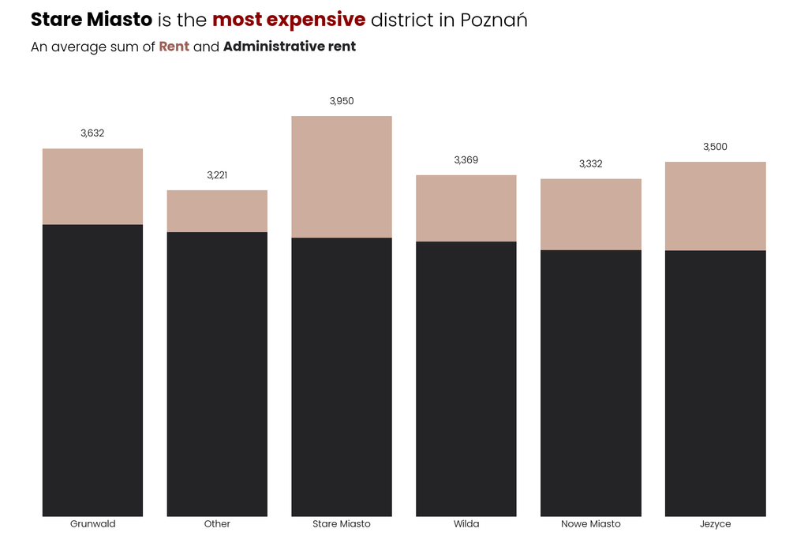

Average rental costs by district (rent + administrative fees)

```python
df_by_districts = df.groupby("Dzielnica")[["Czynsz najmu", "Czynsz administracyjny", "Powierzchnia"]].mean().sort_values("Czynsz najmu", ascending=False).head(10)

fig, ax = plt.subplots(figsize=(12, 8))

ax_text(
    x=-0.5, y=5000,
    size=20,
    ax=ax,
    s="<Stare Miasto> is the <most expensive> district in Poznań",
    color="black",
    font=poppins_light,
    highlight_textprops=[
        {"font": poppins_bold},
        {"color": "darkred", "font": poppins_bold},
    ]
)

ax_text(
    x=-0.5, y=4700,
    size=14,
    ax=ax,
    s="An average sum of <Rent> and <Administrative rent>",
    color="black",
    font=poppins_light,
    highlight_textprops=[
        {"color": cmap(2), "font": poppins_bold},
        {"color": cmap(4), "font": poppins_bold},
    ]
)

# Create stacked bar chart
ax.bar(
    df_by_districts.index,
    df_by_districts["Czynsz najmu"],
    color=cmap(4),
    edgecolor=cmap(4),
    linewidth=1,
    label="Base Rent"
)

ax.bar(
    df_by_districts.index,
    df_by_districts["Czynsz administracyjny"],
    color=cmap(1),
    bottom=df_by_districts["Czynsz najmu"],
    edgecolor=cmap(1),
    linewidth=1,
    label="Administrative Rent"
)

# Add total labels
total_rent = df_by_districts["Czynsz najmu"] + df_by_districts["Czynsz administracyjny"]
for i, total in enumerate(total_rent):
    label = f"{total:,.0f}"
    ax.text(
        x=i, y=total + 100, s=label, ha='center', va='bottom',
        fontsize=10, color='black', font=poppins_light
    )

ax.spines[:].set_visible(False)
ax.get_yaxis().set_visible(False)
ax.tick_params(axis='x', labelsize=10, length=0, rotation=0)

for tick in ax.get_xticklabels():
    tick.set_font(poppins_light)
    tick.set_fontsize(10)

plt.tight_layout()
plt.show()
```

### Market Share by District

**Stare Miasto captures nearly 30% of the rental market**, establishing itself as the dominant supply hub in Poznań. This substantial market share, combined with **Grunwald’s 26%**, means these two districts control **over half of all rental listings** in the city.

**Create market share visualization on map**

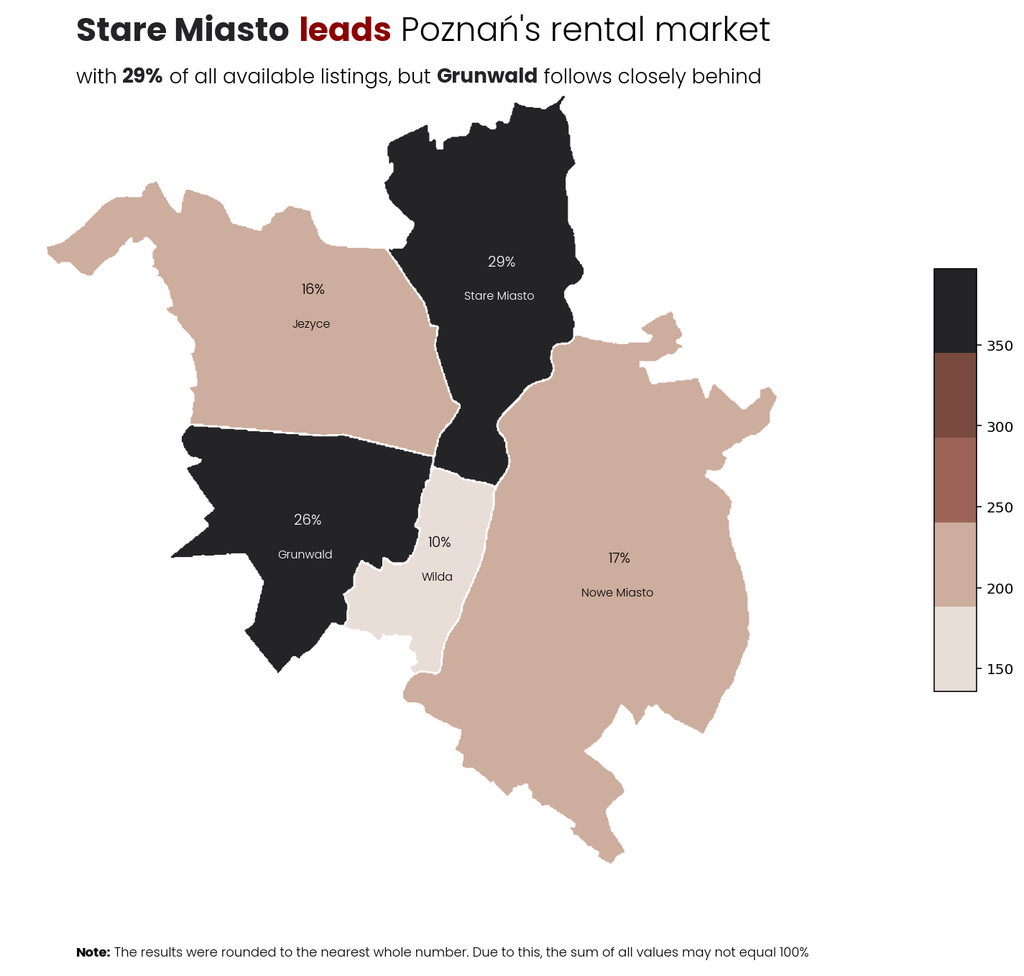

Geographic distribution of rental listings across Poznań districts

```python
# Prepare aggregated data
agg_df = df.groupby('Dzielnica').agg(
    count=('Dzielnica', 'size'),
    avg_total_rent=('Czynsz najmu', 'mean'),
    avg_powierzchnia=('Powierzchnia', 'mean'),
    avg_pokoje=('Liczba pokoi', 'mean'),
    avg_kaucja=('Kaucja', 'mean'),
    avg_pietro=('Budynek Piętro', 'mean')
).reset_index()

# Load geographic data and merge
poznan = gpd.read_file('resources/poznan/dzielnice.shp')
merged_df = pd.merge(poznan, agg_df, left_on="Dzielnica", right_on="Dzielnica", how="left")

legend_settings = {
    'shrink': 0.5,
    'orientation': "vertical",
    'aspect': 10,
    'pad': 0.1,
}

fig, ax = plt.subplots(figsize=(12, 10))

merged_df.plot(
    column='count', ax=ax, legend=True, cmap=cmap,
    legend_kwds=legend_settings
)

fig_text(
    x=0.15, y=0.95,
    s="<Stare Miasto> <leads> Poznań's rental market",
    size=23,
    font=poppins_light,
    highlight_textprops=[
        {"color": cmap(4), "font": poppins_bold},
        {"color": "darkred", "font": poppins_bold},
    ],
)

fig_text(
    x=0.15, y=0.9,
    s="with <29%> of all available listings, but <Grunwald> follows closely behind",
    size=14,
    font=poppins_light,
    highlight_textprops=[
        {"color": cmap(4), "font": poppins_bold},
        {"color": cmap(4), "font": poppins_bold},
    ],
)

# Add district labels and percentages
for idx, row in merged_df.iterrows():
    if pd.notna(row['count']):
        font_color = "white" if row['count'] > 250 else "black"
        point = row.geometry.representative_point()

        ax_text(
            point.x+0.004, point.y,
            f"{str(row['Dzielnica'])}",
            fontsize=8, color=font_color, ha='center',
            font=poppins_light, ax=ax
        )

        ax_text(
            point.x+0.005, point.y+0.01,
            f"{(row['count'] / len(df) * 100):.0f}%",
            fontsize=10, color=font_color, ha='center',
            font=poppins_light, ax=ax
        )

fig_text(
    x=0.15, y=0.05,
    s="<Note:> The results were rounded to the nearest whole number. Due to this, the sum of all values may not equal 100%",
    fontsize=9, font=poppins_light,
    highlight_textprops=[{"color": 'black','font': poppins_bold}]
)

ax.axis("off")
plt.tight_layout()
plt.show()
```

## Property Characteristics

### Room Configuration Preferences

**Two-room apartments dominate Poznań’s rental market** with an overwhelming **53% market share**, confirming the city’s orientation toward compact living solutions. This preference aligns perfectly with the earlier findings about apartment sizes clustering around 40-50 m².

**Analyze room configuration preferences**

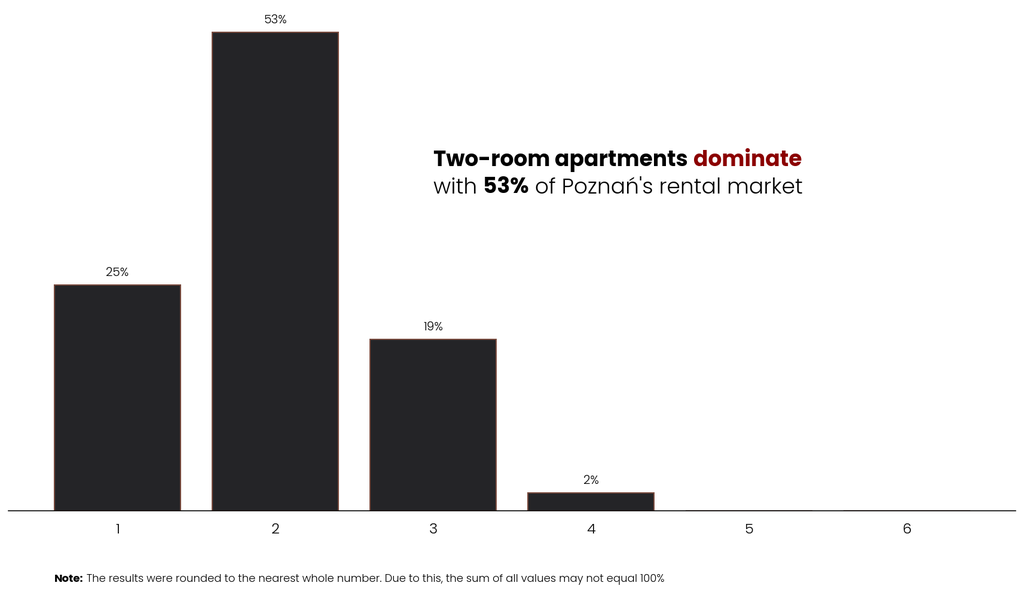

Distribution of apartments by number of rooms

```python
df_rooms = df.groupby("Liczba pokoi").size() / len(df) * 100
df_rooms = df_rooms.round(0).astype(int)

fig, ax = plt.subplots(figsize=(12, 7))

ax_text(
    ax=ax, x=3, y=40,
    s="<Two-room apartments> <dominate> \nwith <53%> of Poznań's rental market",
    font=poppins_light, fontsize=18,
    highlight_textprops=[
        {"color": 'black','font': poppins_bold},
        {"color": 'darkred','font': poppins_bold},
        {"color": 'black','font': poppins_bold},
    ]
)

# Add percentage labels on bars
for i in range(len(df_rooms)):
    if df_rooms.values[i] > 0:
        ax_text(
            ax=ax, x=i+1, y=df_rooms.values[i]+ 2,
            s=f"{df_rooms.values[i]:,}%",
            fontsize=10, color='black', font=poppins_light, ha='center'
        )

ax.bar(
    df_rooms.index, df_rooms.values,
    color=cmap(4), edgecolor=cmap(3), linewidth=1
)

ax.spines[["top", "left", "right"]].set_visible(False)
ax.get_yaxis().set_visible(False)
ax.tick_params(axis='both', labelsize=10, length=0, pad=10)

for tick in ax.get_xticklabels():
    tick.set_font(poppins_light)
    tick.set_fontsize(12)

ax_text(
    ax=ax, x=0.6, y=-7,
    s="<Note:> The results were rounded to the nearest whole number. Due to this, the sum of all values may not equal 100%",
    fontsize=9, font=poppins_light,
    highlight_textprops=[{"color": 'black','font': poppins_bold}]
)

plt.tight_layout()
plt.show()
```

### Geographic Premium Analysis

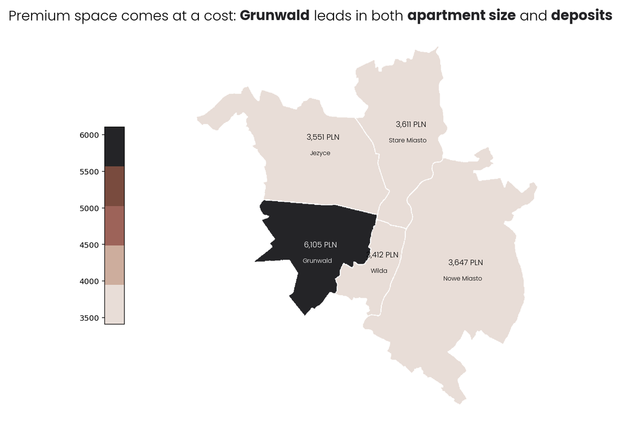

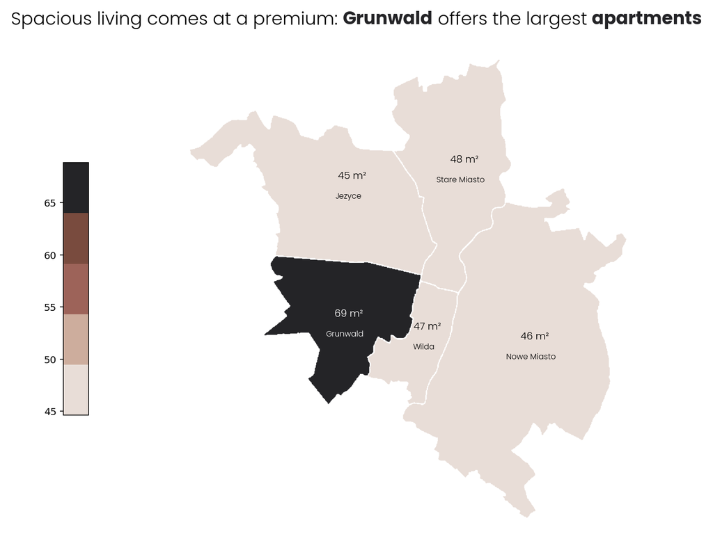

```python
# First Chart - Deposits by District
#| label: deposits-by-district
#| fig-cap: "Average deposit amounts by district"
#| code-summary: "Deposits across Poznań districts"

legend_settings = {
    'shrink': 0.5, 'orientation': "vertical", 'aspect': 10,
    'pad': 0.1, 'location': "left",
}

fig, ax = plt.subplots(1, 1, figsize=(12, 8))

fig_text(
    x=0.5, y=0.95,
    s="Premium space comes at a cost: <Grunwald> leads in both <apartment size> and <deposits>",
    size=18, font=poppins_light, ha='center',
    highlight_textprops=[
        {"color": cmap(4), "font": poppins_bold},
        {"color": cmap(4), "font": poppins_bold},
        {"color": cmap(4), "font": poppins_bold}
    ]
)

merged_df.plot(
    column='avg_kaucja', ax=ax, legend=True, cmap=cmap,
    legend_kwds=legend_settings
)

for idx, row in merged_df.iterrows():
    if pd.notna(row['avg_kaucja']):
        font_color = "white" if row['avg_kaucja'] > 5000 else "black"
        point = row.geometry.representative_point()

        ax_text(
            point.x+0.004, point.y,
            f"{str(row['Dzielnica'])}",
            fontsize=8, color=font_color, ha='center',
            font=poppins_light, ax=ax
        )
        ax_text(
            point.x+0.007, point.y+0.01,
            f"{row['avg_kaucja']:,.0f} PLN",
            fontsize=10, color=font_color, ha='center',
            font=poppins_light, ax=ax
        )

ax.axis("off")
plt.tight_layout()
plt.show()

# Second Chart - Apartment Sizes by District
#| label: apartment-sizes-by-district
#| fig-cap: "Average apartment sizes by district"
#| code-summary: "Apartment areas across Poznań districts"

legend_settings = {
    'shrink': 0.5, 'orientation': "vertical", 'aspect': 10,
    'pad': 0.1, 'location': "left",
}

fig, ax = plt.subplots(1, 1, figsize=(12, 8))

fig_text(
    x=0.5, y=0.95,
    s="Spacious living comes at a premium: <Grunwald> offers the largest <apartments>",
    size=18, font=poppins_light, ha='center',
    highlight_textprops=[
        {"color": cmap(4), "font": poppins_bold},
        {"color": cmap(4), "font": poppins_bold},
    ]
)

merged_df.plot(
    column='avg_powierzchnia', ax=ax, legend=True, cmap=cmap,
    legend_kwds=legend_settings
)

for idx, row in merged_df.iterrows():
    if pd.notna(row['avg_powierzchnia']):
        font_color = "white" if row['avg_powierzchnia'] > 50 else "black"
        point = row.geometry.representative_point()

        ax_text(
            point.x+0.004, point.y,
            f"{str(row['Dzielnica'])}",
            fontsize=8, color=font_color, ha='center',
            font=poppins_light, ax=ax
        )
        ax_text(
            point.x+0.007, point.y+0.01,
            f"{row['avg_powierzchnia']:,.0f} m²",
            fontsize=10, color=font_color, ha='center',
            font=poppins_light, ax=ax
        )

ax.axis("off")
plt.tight_layout()
plt.show()
```

### Subdistrict Analysis

Based on this subdistrict analysis, several key patterns emerge showing **Market Segmentation is Clear**: The chart reveals distinct pricing tiers across Poznań’s districts. Stare Miasto (Old Town) consistently commands premium prices, with most subdistricts clustering in the 2,500-4,500 PLN rent range and requiring deposits of 3,000-4,000 PLN.

**Analyze subdistrict patterns**

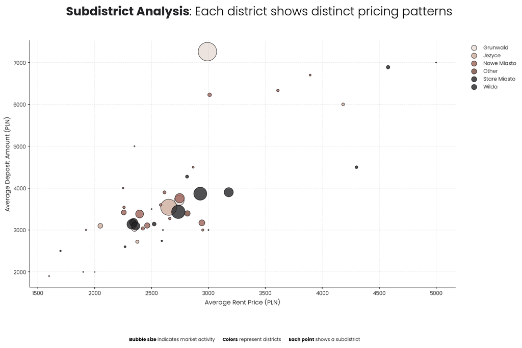

Rent vs. deposit correlation across subdistricts (bubble size = market activity)

```python
# Group by both district and subdistrict
subdistrict_summary = df.groupby(['Dzielnica', 'Obszar w dzielnicy']).agg({
    'Kaucja': 'mean',
    'Czynsz najmu': 'mean',
    'Powierzchnia': 'mean',
    'Dzielnica': 'count'
}).round(0)

subdistrict_summary.columns = ['avg_deposit', 'avg_rent', 'avg_size', 'listing_count']
subdistrict_summary = subdistrict_summary.reset_index()

fig, ax = plt.subplots(figsize=(14, 9))

# Create color mapping for districts
districts = subdistrict_summary['Dzielnica'].unique()
district_colors = {district: cmap(i/(len(districts)-1)) for i, district in enumerate(districts)}

# Create scatter plot for each district
for district in districts:
    district_data = subdistrict_summary[subdistrict_summary['Dzielnica'] == district]

    ax.scatter(
        x=district_data['avg_rent'],
        y=district_data['avg_deposit'],
        s=district_data['listing_count'] * 5,
        color=[district_colors[district]] * len(district_data),
        label=district,
        edgecolors='black',
        linewidth=0.8,
        alpha=0.8
    )

ax.set_xlabel('Average Rent Price (PLN)', fontsize=12, font=poppins_light)
ax.set_ylabel('Average Deposit Amount (PLN)', fontsize=12, font=poppins_light)
ax.spines[['top', 'right']].set_visible(False)
ax.grid(True, alpha=0.3, linestyle='--')

for tick in ax.get_xticklabels() + ax.get_yticklabels():
    tick.set_font(poppins_light)

# Create custom legend
legend_elements = []
for district, color in district_colors.items():
    legend_elements.append(
        plt.scatter([], [], color=color, s=100, label=district,
            edgecolors='black', linewidth=0.8, alpha=0.8)
    )

legend = ax.legend(
    handles=legend_elements, labels=list(district_colors.keys()),
    bbox_to_anchor=(1.02, 1), loc='upper left',
    fontsize=10, frameon=False, markerscale=1
)

for text in legend.get_texts():
    text.set_font(poppins_light)

fig_text(
    x=0.13, y=0.98,
    s="<Subdistrict Analysis>: Each district shows distinct pricing patterns",
    size=23, font=poppins_light,
    highlight_textprops=[{"color": cmap(4), "font": poppins_bold}]
)

fig_text(
    x=0.25, y=0,
    s="<Bubble size> indicates market activity      <Colors> represent districts      <Each point> shows a subdistrict",
    size=9, font=poppins_light, color="black",
    highlight_textprops=[
        {"color": 'black', 'font': poppins_bold},
        {"color": 'black', 'font': poppins_bold},
        {"color": 'black', 'font': poppins_bold}
    ]
)

plt.tight_layout()
plt.show()
```

## Building Characteristics

### Historical Construction Periods

**Contemporary Buildings dominate Poznań’s Rental Market**. The distribution of construction periods across districts reveals interesting patterns about the city’s development and rental stock composition.

**Analyze building age distribution**

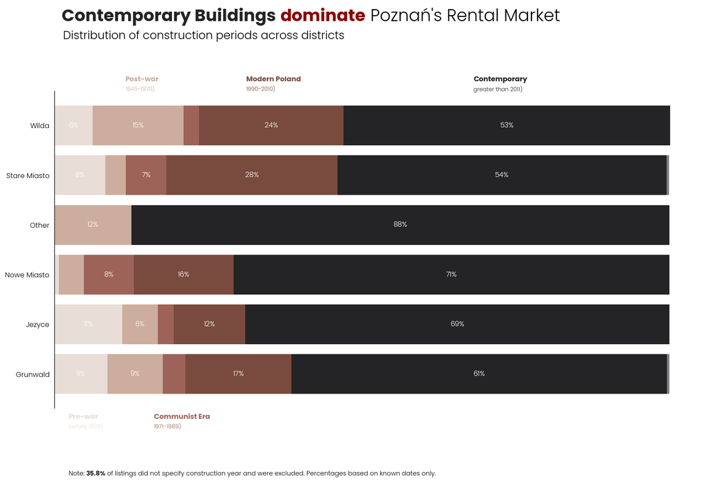

Distribution of construction periods across districts

```python
def categorize_year(year):
    if pd.isna(year):
        return "Unknown"
    elif year < 1939:
        return "Pre-war"
    elif 1945 <= year <= 1970:
        return "Post-war Reconstruction"
    elif 1971 <= year <= 1989:
        return "Communist Era"
    elif 1990 <= year <= 2010:
        return "Modern Poland"
    elif year >= 2011:
        return "Contemporary"
    else:
        return "War Period (1939-1944)"

df['Year_Category'] = df['Rok budowy'].apply(categorize_year)

# Calculate unknown percentage
total_listings = len(df)
unknown_count = len(df[df['Year_Category'] == 'Unknown'])
unknown_percentage = round((unknown_count / total_listings * 100), 1)

# Filter out unknown years
df_known = df[df['Year_Category'] != 'Unknown'].copy()
df_year_districts = df_known.groupby(['Dzielnica', 'Year_Category']).size().reset_index(name='Count')

# Calculate percentages within each district
df_year_districts['Total_by_District'] = df_year_districts.groupby('Dzielnica')['Count'].transform('sum')
df_year_districts['Percentage'] = round((df_year_districts['Count'] / df_year_districts['Total_by_District'] * 100), 1)

# Pivot for visualization
df_viz = df_year_districts.pivot(index='Dzielnica', columns='Year_Category', values='Percentage').fillna(0)

category_order = ['Pre-war', 'Post-war Reconstruction', 'Communist Era', 'Modern Poland', 'Contemporary', 'War Period (1939-1944)']
df_viz = df_viz.reindex(columns=category_order, fill_value=0)

fig, ax = plt.subplots(figsize=(14, 9))

for i in range(len(df_viz.columns)):
    color = 'gray' if i == len(df_viz.columns) - 1 else cmap(i)

    ax.barh(
        df_viz.index,
        df_viz[df_viz.columns[i]],
        left=df_viz.iloc[:, :i].sum(axis=1) if i > 0 else 0,
        color=color,
        label=df_viz.columns[i]
    )

# Add labels for segments > 5%
for i in range(len(df_viz.columns)):
    for j in range(len(df_viz.index)):
        value = df_viz.iloc[j, i]

        if value > 5:
            left_position = df_viz.iloc[j, :i].sum() if i > 0 else 0
            x_position = left_position + value / 2

            ax.text(
                x_position, j, s=f"{value:.0f}%",
                va='center', ha='center', fontsize=10,
                color='white', font=poppins_light
            )

ax.spines[["top", "right", "bottom"]].set_visible(False)
ax.get_xaxis().set_visible(False)
ax.tick_params(axis='y', left=False)

for tick in ax.get_yticklabels():
    tick.set_font(poppins_light)
    tick.set_fontsize(10)

fig_text(
    x=0.09, y=1.02,
    s="<Contemporary Buildings> <dominate> Poznań's Rental Market",
    size=24, font=poppins_light,
    highlight_textprops=[
        {"color": cmap(4), "font": poppins_bold},
        {"color": "darkred", "font": poppins_bold}
    ]
)

fig_text(
    x=0.092, y=0.97,
    s="Distribution of construction periods across districts",
    size=16, font=poppins_light,
)

UNKNOWN_NOTE = f"Note: <{unknown_percentage}%> of listings did not specify construction year and were excluded. Percentages based on known dates only."
fig_text(
    x=0.1, y=0.005, s=UNKNOWN_NOTE, size=9, font=poppins_light,
    highlight_textprops=[{"color": cmap(4), "font": poppins_bold}]
)

# Add period labels
periods = [
    ("Contemporary\n(greater than 2011)", 0.67, 0.87, cmap(4)),
    ("Modern Poland\n(1990-2010)", 0.35, 0.87, cmap(3)),
    ("Post-war\n(1945-1970)", 0.18, 0.87, cmap(1)),
    ("Pre-war\n(before 1939)", 0.1, 0.13, cmap(0)),
    ("Communist Era\n(1971-1989)", 0.22, 0.13, cmap(2))
]

for text, x, y, color in periods:
    fig_text(
        x=x, y=y, s=f"<{text.split('(')[0].strip()}>\n<{text.split('(')[1] if '(' in text else ''}>",
        size=10, font=poppins_light, color=color,
        highlight_textprops=[{"font": poppins_bold}, {"size": 8}]
    )

ax.set_xlim(0, 105)
plt.tight_layout()
plt.show()
```

### Floor Level Impact

Rent remains **consistent** regardless of apartment floor level, suggesting that floor preference has minimal impact on pricing in Poznań’s market.

**Analyze floor level impact on pricing**

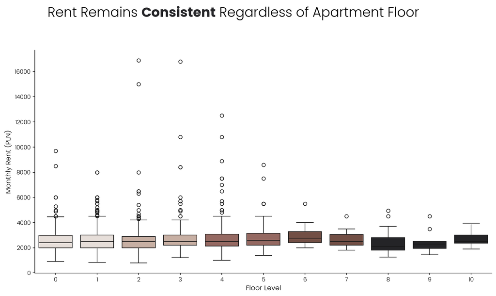

Rental price distribution by floor level

```python
df_floor = df.dropna(subset=["Mieszkanie Piętro", "Czynsz najmu"])
df_floor = df_floor[df_floor["Mieszkanie Piętro"].apply(lambda x: str(x).isdigit())]
df_floor["Mieszkanie Piętro"] = df_floor["Mieszkanie Piętro"].astype(int)

fig, ax = plt.subplots(figsize=(12, 7))

sns.boxplot(
    x="Mieszkanie Piętro", y="Czynsz najmu",
    hue="Mieszkanie Piętro",
    data=df_floor,
    palette=cmap,
    legend=False
)

fig_text(
    x=0.1, y=1,
    s="Rent Remains <Consistent> Regardless of Apartment Floor",
    fontsize=23, font=poppins_light,
    highlight_textprops=[{"color": cmap(4), "font": poppins_bold}]
)

plt.xlabel("Floor Level", fontsize=12, font=poppins_light)
plt.ylabel("Monthly Rent (PLN)", fontsize=12, font=poppins_light)

ax.spines[['top', 'right']].set_visible(False)

for tick in ax.get_xticklabels():
    tick.set_font(poppins_light)
    tick.set_fontsize(10)

for tick in ax.get_yticklabels():
    tick.set_font(poppins_light)
    tick.set_fontsize(10)

plt.tight_layout()
plt.show()
```

## Market Structure

### Listing Source Analysis

**Professional Agencies vastly outnumber Private Landlords** in Poznań’s rental market, indicating a highly professionalized rental ecosystem.

**Analyze market structure by listing source**

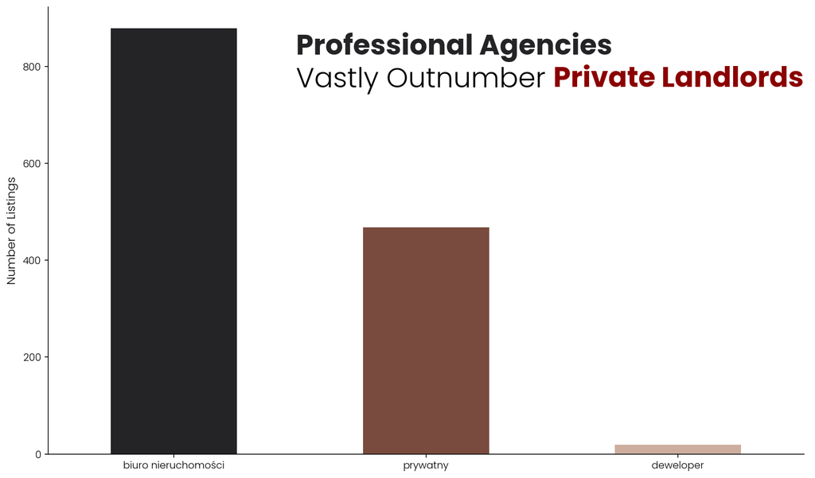

Distribution of listing sources (agencies vs. private landlords)

```python
source_counts = df["Typ ogłoszeniodawcy"].value_counts()

fig, ax = plt.subplots(figsize=(12, 7))

source_counts.plot(kind='bar', color=[cmap(5), cmap(3), cmap(1)])

fig_text(
    x=0.35, y=0.9,
    s="<Professional Agencies> \nVastly Outnumber <Private Landlords>",
    fontsize=28, font=poppins_light,
    highlight_textprops=[
        {"color": cmap(4), "font": poppins_bold},
        {"color": "darkred", "font": poppins_bold},
    ]
)

plt.ylabel("Number of Listings", fontsize=12, font=poppins_light)
ax.set_xlabel(None)
ax.spines[['top', 'right']].set_visible(False)

for tick in ax.get_xticklabels():
    tick.set_font(poppins_light)
    tick.set_fontsize(10)

for tick in ax.get_yticklabels():
    tick.set_font(poppins_light)
    tick.set_fontsize(10)

plt.xticks(rotation=0)
plt.tight_layout()
plt.show()
```

## Cost Structure Analysis

### Heating Infrastructure Impact

**Heating Infrastructure drives Administrative Cost Structure**. Different heating systems significantly impact the administrative costs, with some heating types commanding premium charges.

**Analyze heating infrastructure impact on costs**

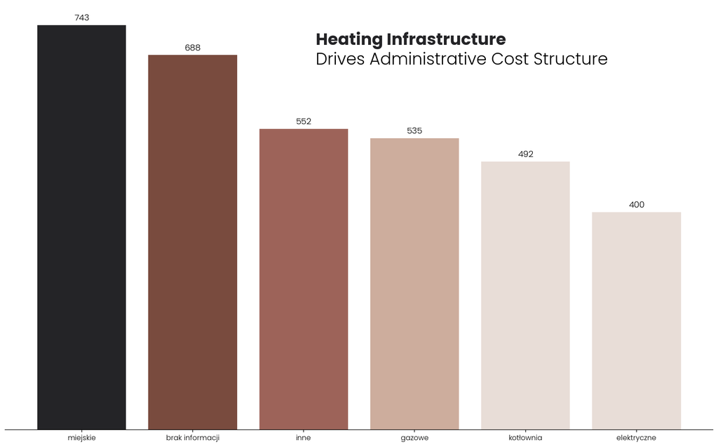

Average administrative rent by heating type

```python
df_filtered = df.dropna(subset=["Czynsz administracyjny", "Ogrzewanie"])
df_filtered = df_filtered[
    (df_filtered["Czynsz administracyjny"] > 0) &
    (df_filtered["Czynsz administracyjny"] < 10000)
]

avg_admin_rent = (
    df_filtered
    .groupby("Ogrzewanie")["Czynsz administracyjny"]
    .mean()
    .sort_values(ascending=False)
)

fig, ax = plt.subplots(figsize=(14, 9))

bars = ax.bar(
    range(len(avg_admin_rent)),
    avg_admin_rent.values,
    color=[cmap_unreversed(i) for i in range(len(avg_admin_rent))]
)

fig_text(
    x=0.44, y=0.9,
    s="<Heating Infrastructure> \nDrives Administrative Cost Structure",
    fontsize=23, font=poppins_light,
    highlight_textprops=[{"color": cmap(4), "font": poppins_bold}]
)

ax.set_xticks(range(len(avg_admin_rent)))
ax.set_xticklabels(avg_admin_rent.index, rotation=0, ha='center', fontsize=14, font=poppins_light)

# Add value labels on bars
for i, bar in enumerate(bars):
    height = bar.get_height()
    ax.text(bar.get_x() + bar.get_width()/2., height + 5,
            f'{height:.0f}', ha='center', va='bottom',
            fontsize=12, font=poppins_light, color='black')

ax.spines[["top", "right", "left"]].set_visible(False)
ax.grid(axis='y', alpha=0.3, linestyle='-', linewidth=0.5)
ax.set_axisbelow(True)
ax.get_yaxis().set_visible(False)

for tick in ax.get_xticklabels():
    tick.set_font(poppins_light)
    tick.set_fontsize(10)

plt.tight_layout()
plt.show()
```

## Amenities Analysis

### Equipment Correlation with Rent

**Modern Amenities show stronger links to premium pricing than basic features**. This analysis reveals which amenities correlate most strongly with higher rental prices.

**Analyze equipment impact on rent pricing**

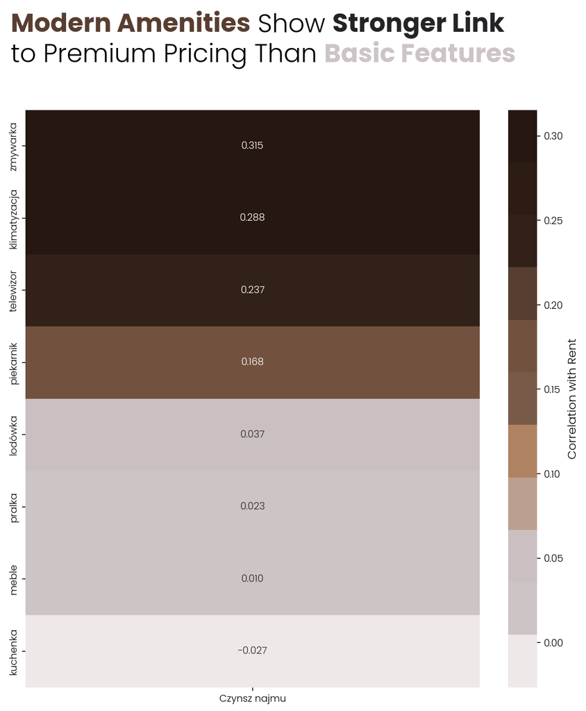

Correlation between equipment amenities and rental prices

```python
def parse_equipment_safe(x):
    try:
        return ast.literal_eval(x) if isinstance(x, str) else []
    except (ValueError, SyntaxError):
        return []

df_eq = df.dropna(subset=["Wyposażenie", "Czynsz administracyjny"]).copy()
df_eq["Wyposażenie"] = df_eq["Wyposażenie"].apply(parse_equipment_safe)

# Create one-hot encoding for equipment
eq_dummies = df_eq["Wyposażenie"].apply(pd.Series).stack().reset_index(level=1, drop=True).to_frame("item")
eq_dummies["present"] = 1
df_eq = df_eq.drop("Wyposażenie", axis=1).join(eq_dummies)

df_eq = df_eq.pivot_table(index=df_eq.index, columns="item", values="present", fill_value=0).join(df_eq["Czynsz najmu"])

correlation = df_eq.corr(numeric_only=True)["Czynsz najmu"].drop("Czynsz najmu").sort_values(ascending=False)

fig, ax = plt.subplots(figsize=(10, 10))

heatmap = sns.heatmap(
    correlation.to_frame(),
    annot=True,
    cmap=cmap_x85,
    vmin=correlation.min(),
    vmax=correlation.max(),
    cbar_kws={'label': 'Correlation with Rent'},
    fmt='.3f',
    annot_kws={'fontsize': 10, 'font': poppins_light},
)

fig_text(
    x=0.15, y=1,
    s="<Modern Amenities> Show <Stronger Link> \nto Premium Pricing Than <Basic Features>",
    fontsize=26, font=poppins_light,
    highlight_textprops=[
        {"color": cmap_x85(7), "font": poppins_bold},
        {"color": cmap(4), "font": poppins_bold},
        {"color": cmap_x85(1), "font": poppins_bold},
    ]
)

ax.set_xlabel("", fontsize=12, font=poppins_light)

for tick in ax.get_yticklabels():
    tick.set_fontproperties(poppins_light)
    tick.set_fontsize(10)

for tick in ax.get_xticklabels():
    tick.set_fontproperties(poppins_light)
    tick.set_fontsize(10)

cbar = heatmap.collections[0].colorbar
cbar.ax.set_ylabel('Correlation with Rent', font=poppins_light, fontsize=12)

for tick in cbar.ax.get_yticklabels():
    tick.set_fontproperties(poppins_light)
    tick.set_fontsize(10)

for spine in ax.spines.values():
    spine.set_visible(False)

fig.subplots_adjust(left=0.3)
plt.tight_layout()
plt.show()
```

### Equipment Prevalence

**Basic Appliances dominate listings, Premium Features rare**. This analysis shows the distribution of amenities across all listings.

**Show distribution of amenities**

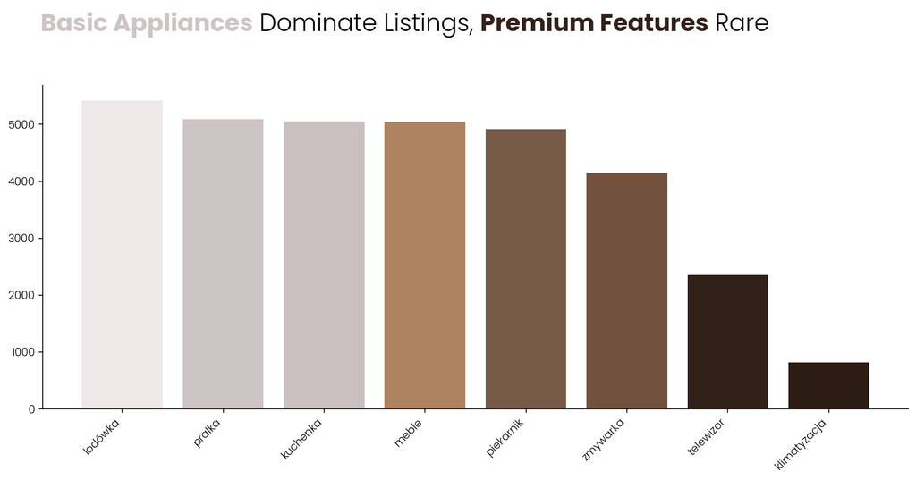

Prevalence of different amenities across listings

```python
top_items = df_eq.drop(columns="Czynsz najmu").sum().sort_values(ascending=False)

fig, ax = plt.subplots(figsize=(12, 6))

bars = ax.bar(
    range(len(top_items)),
    top_items.values,
    color=[cmap_x85(i/len(top_items)) for i in range(len(top_items))]
)

fig_text(
    x=0.07, y=1,
    s="<Basic Appliances> Dominate Listings, <Premium Features> Rare",
    fontsize=22, fontproperties=poppins_light,
    highlight_textprops=[
        {"color": cmap_x85(1), "font": poppins_bold},
        {"color": cmap_x85(8), "font": poppins_bold},
    ]
)

ax.set_xticks(range(len(top_items)))
ax.set_xticklabels(top_items.index, rotation=45, ha='right')

for tick in ax.get_xticklabels():
    tick.set_fontproperties(poppins_light)
    tick.set_fontsize(10)

for tick in ax.get_yticklabels():
    tick.set_fontproperties(poppins_light)
    tick.set_fontsize(10)

ax.spines[["top", "right"]].set_visible(False)
plt.tight_layout()
plt.show()
```

## Security Analysis

### Security Features Impact

**Security Features show minimal impact on rental prices** despite their growing prevalence in the market.

**Analyze security feature impact**

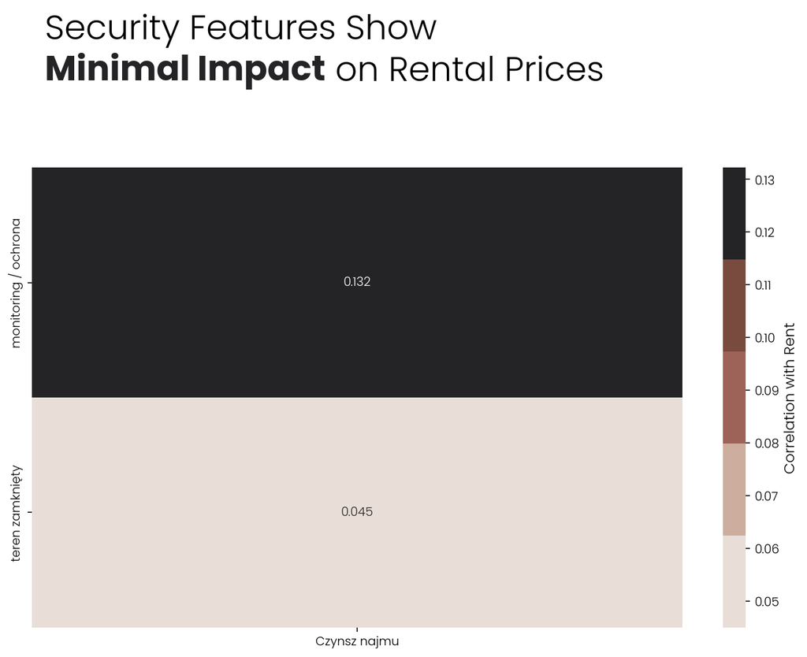

Correlation between security features and rental prices

```python
def parse_security_flex(x):
    if isinstance(x, str):
        try:
            parsed = ast.literal_eval(x)
            if isinstance(parsed, list):
                return parsed
            else:
                return [parsed]
        except:
            return [x]
    elif isinstance(x, list):
        return x
    else:
        return []

df_sec = df.dropna(subset=["Bezpieczeństwo", "Czynsz najmu"]).copy()
df_sec["Bezpieczeństwo"] = df_sec["Bezpieczeństwo"].apply(parse_security_flex)

# One-hot encoding for security features
sec_dummies = df_sec["Bezpieczeństwo"].apply(pd.Series).stack().reset_index(level=1, drop=True).to_frame("item")
sec_dummies["present"] = 1
df_sec = df_sec.drop("Bezpieczeństwo", axis=1).join(sec_dummies)

df_sec = df_sec.pivot_table(index=df_sec.index, columns="item", values="present", fill_value=0).join(df_sec["Czynsz najmu"])

correlation = df_sec.corr(numeric_only=True)["Czynsz najmu"].drop("Czynsz najmu").sort_values(ascending=False)

fig, ax = plt.subplots(figsize=(10, 7))

heatmap = sns.heatmap(
    correlation.to_frame(),
    annot=True,
    cmap=cmap,
    vmin=correlation.min(),
    vmax=correlation.max(),
    cbar_kws={'label': 'Correlation with Rent'},
    fmt='.3f',
    annot_kws={'fontsize': 10, 'font': poppins_light}
)

fig_text(
    x=0.08, y=1.05,
    s="Security Features Show \n<Minimal Impact> on Rental Prices",
    fontsize=28, fontproperties=poppins_light,
    highlight_textprops=[{"color": cmap(5), "font": poppins_bold}]
)

ax.set_xlabel("", fontsize=12, fontproperties=poppins_light)

for tick in ax.get_yticklabels():
    tick.set_fontproperties(poppins_light)
    tick.set_fontsize(10)

for tick in ax.get_xticklabels():
    tick.set_fontproperties(poppins_light)
    tick.set_fontsize(10)

cbar = heatmap.collections[0].colorbar
cbar.ax.set_ylabel('Correlation with Rent', fontproperties=poppins_light, fontsize=12)

for tick in cbar.ax.get_yticklabels():
    tick.set_fontproperties(poppins_light)
    tick.set_fontsize(10)

for spine in ax.spines.values():
    spine.set_visible(False)

plt.tight_layout()
plt.show()
```

### Security vs. Non-Security Rent Comparison

Despite weak correlation, **secured properties command higher rents** when comparing median values.

**Compare rent levels for secured vs non-secured properties**

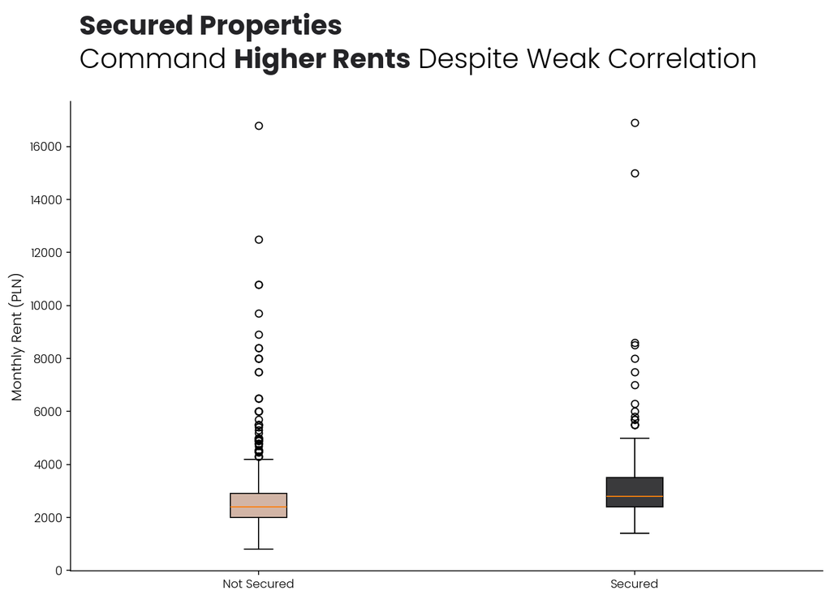

Rent distribution: secured vs. non-secured properties

```python
def is_secured(f):
    try:
        if isinstance(f, str):
            f = ast.literal_eval(f)
        if isinstance(f, list):
            return int(any("monitoring" in x.lower() or "teren zamknięty" in x.lower() for x in f if isinstance(x, str)))
    except:
        return 0
    return 0

df["czy_strzezone"] = df["Bezpieczeństwo"].apply(is_secured)

fig, ax = plt.subplots(figsize=(10, 7))

box_colors = [cmap(1), cmap(5)]
boxplot = ax.boxplot(
    [df[df["czy_strzezone"] == 0]["Czynsz najmu"].dropna(),
     df[df["czy_strzezone"] == 1]["Czynsz najmu"].dropna()],
    patch_artist=True,
    tick_labels=["Not Secured", "Secured"]
)

for patch, color in zip(boxplot['boxes'], box_colors):
    patch.set_facecolor(color)
    patch.set_alpha(0.9)

fig_text(
    x=0.1, y=1,
    s="<Secured Properties> \nCommand <Higher Rents> Despite Weak Correlation",
    fontsize=23, fontproperties=poppins_light,
    highlight_textprops=[
        {"color": cmap(5), "font": poppins_bold},
        {"color": cmap(5), "font": poppins_bold},
    ]
)

ax.set_ylabel("Monthly Rent (PLN)", fontsize=12, font=poppins_light)

for tick in ax.get_xticklabels():
    tick.set_fontproperties(poppins_light)
    tick.set_fontsize(10)

for tick in ax.get_yticklabels():
    tick.set_fontproperties(poppins_light)
    tick.set_fontsize(10)

ax.spines[["top", "right"]].set_visible(False)
plt.tight_layout()
plt.show()
```

### Security Feature Market Penetration

**Security Features becoming standard** - Nearly half of all listings now include security features.

**Show prevalence of security features**

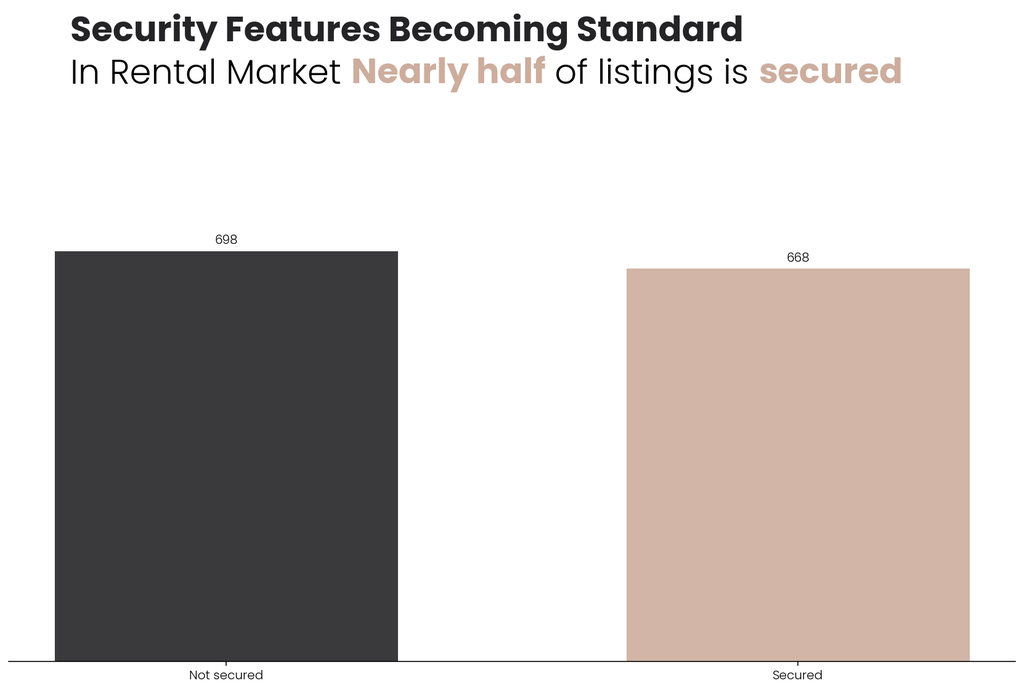

Market penetration of security features

```python
def has_security(x):
    if isinstance(x, str):
        return int("monitoring" in x.lower() or "teren zamknięty" in x.lower())
    if isinstance(x, list):
        return int(any("monitoring" in i.lower() or "teren zamknięty" in i.lower() for i in x if isinstance(i, str)))
    return 0

df["czy_strzezone"] = df["Bezpieczeństwo"].apply(has_security)
counts = df["czy_strzezone"].value_counts().rename(index={1: "Secured", 0: "Not secured"})

fig, ax = plt.subplots(figsize=(12, 7))

bar_colors = [cmap(5), cmap(1)]
bars = ax.bar(counts.index, counts.values, color=bar_colors, alpha=0.9, width=0.6)

# Add value labels on bars
for i, bar in enumerate(bars):
    height = bar.get_height()
    ax.text(bar.get_x() + bar.get_width()/2., height + height*0.01,
            f'{int(height):,}', ha='center', va='bottom',
            fontproperties=poppins_light, fontsize=10)

fig_text(
    x=0.1, y=1.1,
    s="<Security Features Becoming Standard> \nIn Rental Market <Nearly half> of listings is <secured>",
    fontsize=28, fontproperties=poppins_light,
    highlight_textprops=[
        {"color": cmap(5), "font": poppins_bold},
        {"color": cmap(1), "font": poppins_bold},
        {"color": cmap(1), "font": poppins_bold},
    ]
)

for tick in ax.get_xticklabels():
    tick.set_fontproperties(poppins_light)
    tick.set_fontsize(10)

for tick in ax.get_yticklabels():
    tick.set_fontproperties(poppins_light)
    tick.set_fontsize(10)

ax.spines[["top", "right", "left"]].set_visible(False)
ax.get_yaxis().set_visible(False)
plt.tight_layout()
plt.show()
```

## Key Findings & Investment Recommendations

### Market Summary

Based on this comprehensive analysis of Poznań’s rental market, several key insights emerge:

**Market Structure:**

- **Compact living dominates**: 53% of properties are 2-room apartments averaging 40-50 m²
- **Professional market**: Agencies vastly outnumber private landlords
- **Price concentration**: Most rents fall in the 2,000-3,000 PLN range

**Geographic Patterns:**

- **Stare Miasto** commands premium prices but holds 29% market share
- **Grunwald** offers largest apartments with highest deposits
- **Clear market segmentation** by district with distinct pricing tiers

**Investment Opportunities:**

- **Premium segment underexplored**: Limited supply of 80+ m² properties
- **Modern amenities matter**: Dishwashers and AC show strongest rent correlation
- **Security features standard**: Nearly half of listings include security, becoming baseline expectation

**Cost Drivers:**

- **Heating infrastructure** significantly impacts administrative costs
- **Contemporary buildings** dominate the rental stock
- **Floor level has minimal impact** on pricing

This analysis positions Poznań as a stable, efficient rental market with clear opportunities for strategic investment in underserved premium segments while maintaining strong fundamentals in the core compact living sector.